# Module 7

Group: 12  
Darko Petrov  
Alexander Lendon

## Q.1

### 1.

#### (a)

In a consensus optimisation if the optimal value is reached it means that the vectors at each node are identical. An optimal value of zero means that the vectors $x_i$ at each node $v_i$ are equal because the objective value represents the distance between vectors at each pair of nodes. the set of all optimal solutions is given by: $$ \{(x_1,x_2,\cdots,x_n) \in (R^m)^n:x_1=x_2=\cdots=x_n\} $$

The gradient of the equation (4) can be gotten by taking the derivative with respect to $\theta_i$:

$$ \frac{\partial}{\partial\theta_i} (\sum_{i}f_i(\theta_i) + \frac{\rho}{2} \sum_{i,j} a_{ij}\| \theta_i - \theta_j \|^2_2) = \nabla f_i(\theta_i) + \rho \sum_{i,j} a_{ij} (\theta_i - \theta_j) $$

Now using the gradient we can write the iteration of GD with:

$$ \theta_i^{k+1} = \theta_i^k - \alpha (\nabla f_i(\theta_i) + \rho \sum_{i,j} a_{ij} (\theta_i - \theta_j)) $$

Were $\alpha$ is the learning rate.

#### (b)

The original objective function is:

$$\sum_{i,j} a_{ij} \|x_i - x_j\|^2_2$$

Expanding the squared norm, we get:

$$\sum_{i,j} a_{ij} (x_i^T x_i - 2x_i^T x_j + x_j^T x_j)$$

Rearranging the terms, we get:

$$\sum_{i,j} a_{ij} x_i^T x_i - \sum_{i,j} a_{ij} x_i^T x_j + \sum_{i,j} a_{ij} x_j^T x_j$$

This can be written as:

$$\sum_{i,j} L_{ij} x_i^T x_j$$

The Laplacian matrix $L = (L_{ij})$ can be expressed as a degree matrix $D$ and the adjacency matrix $A$ where $L = D - A$. In our example we have a weighted graph. In this case the degree of a node is the sum of the weights of its edges, and the adjacency matrix uses the weights of the edges.

For an undirected weighted graph, the elements of the Laplacian matrix $L$ are defined as follows:

- For $i \neq j$, $L_{ij} = -a_{ij}$ if there is an edge between nodes $v_i$ and $v_j$, and $L_{ij} = 0$ otherwise.
- For $i = j$, $L_{ii} = \sum_{j \neq i} a_{ij}$, which is the sum of the weights of all edges connected to node $v_i$.

#### (c)

Defining the objective function $f(X)$:

$$f(X) = \sum_{i,j} L_{ij} x_i^T x_j$$

where $X = [x_1, x_2, ..., x_n]^T$ is the matrix of vectors at each node, and $L_{ij}$ are the elements of the Laplacian matrix we defined previously.

Taking the gradient of this function with respect to $x_k$,
$$\frac{\partial}{\partial x_k}x_i^T x_j = \begin{cases} x_i & \text{if }k = j \\ x_j & \text{if }k = i \end{cases} $$

So the gradient of $f(x_i)$ can be written as:$ $$\nabla f(x_i) = 2 \sum_{j} L_{ij} x_j$$

Now, a step of the gradient descent algorithm updates each vector $x_i$ as follows:

$$x_i^{(t+1)} = x_i^{(t)} - \mu \nabla f(x_i^{(t)})$$

where $\mu$ is the step size. This update is performed for all $i = 1, 2, ..., n$.

#### (d)

The gradient descent update rule was defined in the previous answer as: $$x_i^{(t+1)} = x_i^{(t)} - \mu \nabla f(x_i^{(t)})$$

If we substitute in the expression for the gradient also found in the previous answer: $$\nabla f(x_i) = 2 \sum_{j} L_{ij} x_i$$ the gradient descent can be written as: $$x_i^{(t+1)} = x_i^{(t)} - 2\mu \sum_{j} L_{ij} x_i^{(t)}$$ We can now replace $L_{ij}$ as we found in part b) that: $$ L_{ij} = -a_{ij} \quad \text{if} \quad j\neq i \\ \\ L_{jj} = \sum_{j\neq i} a_{ij} \quad \text{otherwise} $$ Resulting in the following expression for the gradient descent: $$x_i^{(t+1)} = x_i^{(t)} + 2\mu \sum_{j\neq i} a_{ij}(x_i^{(t)} - x_j^{(t)})$$ A gossip protocol update rule can be written as: $$ x_i^{(t+1)}=\sum_j w_{ij}x_j^{(t)} $$ Rewriting the expression for gradient descent as this gossip protocol update rule would mean that: $$ w_{ij} \begin{cases} \delta_{ij} + 2\mu a_{ij} & i\neq j \\ 1 - 2\mu\sum_{j\neq i}a_{ij} & i=j \end{cases} $$ where $\delta_{ij}\begin{cases} 0 & i \neq j \\ 1 & i=j \end{cases}$

#### (e)

The update rule for the consensus optimization problem can be written as:

$$ x_i^{(t+1)} = x_i^{(t)} - \alpha \sum_{j} a_{ij} (x_i^{(t)} - x_j^{(t)}) \tag{2} $$

where $\alpha$ is the step size.

Summing over all $i$, we get:

$$ \sum_{i=1}^{n} x_{i}^{(t+1)} = \sum_{i=1}^{n} x_{i}^{(t)} - \alpha \sum_{i=1}^{n} \sum_{j} a_{ij} (x_i^{(t)} - x_j^{(t)}) $$

The second term on the right-hand side can be rewritten as:

$$ \alpha \sum_{i=1}^{n} \sum_{j} a_{ij} (x_i^{(t)} - x_j^{(t)}) = \alpha \sum_{i,j} a_{ij} x_i^{(t)} - \alpha \sum_{i,j} a_{ij} x_j^{(t)} $$

Using the fact that $a_{ij} = a_{ji}$ and $a_{ij}x_i^{(t)} = a_{ji}x_j^{(t)}$, we can see that the two terms are equal and their difference is zero:

$$ \alpha \sum_{i,j} a_{ij} x_i^{(t)} - \alpha \sum_{i,j} a_{ij} x_j^{(t)} = 0 $$

Therefore, we have:

$$ \sum_{i=1}^{n} x_{i}^{(t+1)} = \sum_{i=1}^{n} x_{i}^{(t)} $$

#### (f)

Given the results from parts (a) and (e), we can determine the convergence of the Gradient Descent (GD) algorithm.

From part (a), we know that the objective function of the consensus optimization problem is convex. This means that there exists a global minimum.

From part (e), we have shown that the sum of the variables $x_i$ does not change over iterations, i.e.,

$$ \sum_{i=1}^{n} x_{i}^{(t+1)} = \sum_{i=1}^{n} x_{i}^{(t)} $$

This implies that the sum of the variables $x_i$ is a conserved quantity throughout the iterations of the GD algorithm.

Therefore, the GD algorithm will converge to a point where the sum of the variables $x_i$ equals the initial sum, i.e.,

$$ \sum_{i=1}^{n} x_{i}^{*} = \sum_{i=1}^{n} x_{i}^{(0)} $$

where $x_i^{*}$ denotes the values of the variables at the convergence point.

In other words, the GD algorithm will converge to a solution where the variables $x_i$ are such that their sum remains equal to the initial sum. This is the consensus point, which is the solution to the consensus optimization problem. The exact values of $x_i$ at the convergence point will depend on the specific values of $a_{ij}$ and the initial values $x_{i}^{(0)}$.

### 2

#### (a)

The gradient of the equation (4) can be gotten by taking the derivative with respect to $\theta_i$:

$$ \frac{\partial}{\partial\theta_i} (\sum_{i}f_i(\theta_i) + \frac{\rho}{2} \sum_{i,j} a_{ij}\| \theta_i - \theta_j \|^2_2) = \nabla f_i(\theta_i) + \rho \sum_{i,j} a_{ij} (\theta_i - \theta_j) $$

Now using the gradient we can write the iteration of GD with:

$$ \theta_i^{k+1} = \theta_i^k - \alpha (\nabla f_i(\theta_i) + \rho \sum_{i,j} a_{ij} (\theta_i - \theta_j)) $$

Were $\alpha$ is the learning rate.

#### (b)

$\rho$ is a variable that regulates the correlation between the nodes. If $\rho$ is small, the nodes are not correlated and the optimization problem is the same as the original problem. If $\rho$ is large, the nodes are highly correlated and the optimization problem is the same as the average of the nodes. For optimizing $\min_\theta \sum_{i}f_i(\theta)$, we want the nodes to be highly correlated, so $\rho = 1$ should give a good correlation between the nodes and a good approximation of the original problem.

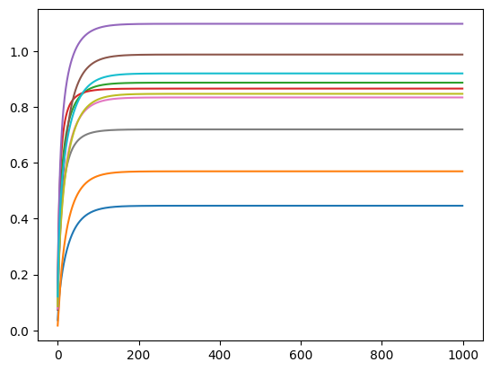

```python
import numpy as np
import matplotlib.pyplot as plt
np.random.seed(42)

def get_Y(beta, theta0, X):
    Y = []
    for x_i in X:
        t_i = np.matmul(theta0.T, x_i)
        odds = np.exp(beta*t_i)
        Y.append(np.random.choice(a=[-1, 1], size=1, p= [odds/(1+odds), 1/(1+odds)])[0])
    return Y

def logistic_loss(x_i, y_i, theta_i):
    return np.sum(np.log(1+np.exp(y_i*np.dot(x_i, theta_i.T))))/100

def logistic_loss_gradient(x_ik, y_ik, theta_i):
    return ((y_ik*x_ik)*(np.exp(y_ik*np.dot(x_ik, theta_i.T))))/(1+np.exp(y_ik*np.dot(x_ik, theta_i.T)))


def gradient_decent(data, num_iterations, rho, learning_rate):
    theta = [np.zeros(data[i][0].shape[1]) for i in range(len(data))]
    # obj_val = []
    theta_hat = []
    for _ in range(num_iterations):
        for node in range(len(data)):
            x_i, y_i = data[node]
            for k in range(len(x_i)):
                theta[node] = theta[node] - learning_rate*(logistic_loss_gradient(x_i[k], y_i[k], theta[node])+rho*sum(theta[node]-theta[(node+1)%len(data)]))

        x_i, y_i = data[0]
        # obj_val.append(logistic_loss(x_i, y_i, theta[0]) + (rho/2)*np.linalg.norm(theta[0]-theta[1])**2)
        theta_hat.append(theta[0])

    return theta_hat



#################################################################################################################
# Generate synthetic data
# Given value
num_nodes = 5
num_samples = 100
num_features = 10

# guess value
rho = 0
learning_rate = 0.01
num_iterations = 1000

# Generate random data for each node
data = []
for i in range(num_nodes):
    x_i = np.random.randn(num_samples, num_features)
    y_i = get_Y(1, np.ones(num_features), x_i)
    data.append((x_i, y_i))

theta_h = gradient_decent(data, num_iterations, rho, learning_rate)
aa = np.mean(theta_h, axis=1)
# print(aa[-1])
plt.plot(theta_h)
plt.show()
# [0.97835677 1.13778643 1.48227384 1.22894021 1.74387807 1.76930956 1.42357212 1.16881394 1.57878946 1.64460066]
# [1.1875784  1.29881922 1.48399113 1.45819885 1.33514147 1.3587904 1.51231231 1.15671856 1.25859282 1.37243777]
```

#### (d)

```
0
0.001
0.01
0.1
0.2
0.5
0.99
```

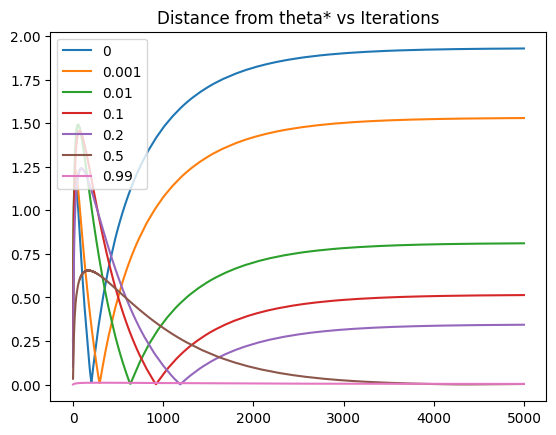

```python
rhos = [0, 1e-3, 1e-2, 0.1, 0.2, 0.5, 0.99]
learning_rate = 0.01
num_iterations = 5000
# rhos = [0.1]
theta_star = gradient_decent(data, num_iterations, 1, learning_rate)
# plt.figure(1)
# plt.figure(2)
theta_hist= []
for rho in rhos:
    print(rho)
    theta_h = gradient_decent(data, num_iterations, rho, learning_rate)
    # plt.figure(1)
    # plt.plot(obj_val)
    err= []
    for i in range(len(theta_h)):
        err.append(np.linalg.norm(np.array(theta_h[i])-np.array(theta_star[i])))
    # plt.figure(2)
    plt.plot(err)
    theta_hist.append(np.linalg.norm(np.array(theta_h[-1])-np.array(theta_star[-1])))

# plt.figure(1)
# plt.legend(rhos)
# plt.title("Objective value vs Iterations")
# plt.show()
# plt.figure(2)
plt.legend(rhos)
plt.title("Distance from theta* vs Iterations")
plt.show()
```

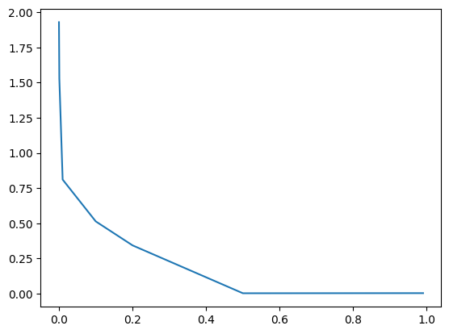

```python
plt.plot(rhos, theta_hist)
```

#### (d)

For the plot above we used $\rho = 1$ to calculate $\theta^*$ and plotting the error for different values of $\rho$. We can see that the error is minimized when $\rho$ is approaching 1. Form the second plot we can see that the error is lowering as the correlation of the nodes is increased. This is as the nodes are getting more correlated and the optimization problem is getting closer to the original problem.